# What Content Would Give New Twitch Streamers The Most Views?

Alex Tran, Brian Tran, and Sylvia Yee

- Introduction
  - Background Information & Purpose
  - Datasets/Packages/Libraries
- Data Cleaning & Tidying
- Exploratory Data Analysis
  - Twitch Top 20 Games: Total Games Per Genre
  - Twitch Top 20 Games: Total Average Viewership vs Genre
  - Twitch Top 10 Genres: Total Monthly Stream Time Per Genre
  - Twitch Top 10 Genres: Total Average Viewers Per Streamer By Genre
  - Twitch Top 10 Genres: Total Average Genre Rank Over Time
  - Twitch Top 10 Genres: Total Occurrences of a Genre in Top 20 Game Rankings
- Hypothesis Testing & Machine Learning
  - Twitch Top 10 Genres: Average Viewers vs Hours Streamed
- Conclusion
  - Further Work
  - Further Resources

### Introduction

#### Background Information & Purpose

For our final tutorial, we will be analyzing the trends in streaming culture through a platform called [Twitch](https://www.twitch.tv/). Created in 2011, Twitch continues to be used for live-streaming various types of entertainment, such as video game playthroughs, esport competition broadcasts, and more<sup>[1](https://en.wikipedia.org/wiki/Twitch_(service))</sup>. Streamers, or users who stream, are able to earn money through the platform by joining either Twitch’s Partner or [Affiliate](https://affiliate.twitch.tv/) program. However, Twitch has a very strict and rigorous set of criterion for streamers who desire to join the Partner program. As such, we will focus on the Affiliate program instead since becoming an Affiliate is much easier than becoming a Partner.

For a streamer to join the Affiliate program, streamers need to have at least 50 followers, and within the last 30 days, the streamers must:

- Stream at least 500 total minutes (8.4 hrs) of broadcast
- Have 7 unique broadcast days
- Obtain an average of 3 or more concurrent viewers<sup>[2](https://affiliate.twitch.tv/)</sup>

Consequently, for a streamer who wants to earn some money through Twitch, they would need to join the Affiliate program. And to do so, they would need to find and live-stream content that other Twitch users would like to watch and be entertained by. Therefore, our group decided to analyze the different trends in streaming culture so that we are able to discover what streaming content is most viewed and well-liked. Ultimately, we hope to give valuable information for people like streamers who would like to attract more viewers and earn money through the Twitch streaming services.

#### Datasets/Packages/Libraries

Using this [dataset](https://www.kaggle.com/rankirsh/evolution-of-top-games-on-twitch) from Kaggle.com, we will extract the Top 20 most popular games for each month from January 2016 to October 2021; the popularity will be based on the rank of the games for each month. We decided to only look at the Top 20 most popular games for each month because too much data points will clobber our graphs which will decrease readability and reduce the effectiveness of our analyses. Additionally, we will use the game_genres.csv file for our analysis as it provides us the genres for each game that was categorized by Twitch. We manually inputted the data in the game_genres.csv file because we could not find any existing dataset that gives the information that we needed and we could not extract the information from Twitch’s website. Lastly, we will also be using the following Python packages/libraries for this tutorial:

```python
import numpy as np

import pandas as pd

import matplotlib.pyplot as plt
import matplotlib.cm as cm
import matplotlib.ticker as tick

import statsmodels.formula.api as smf
```

Here are the documentations for each of the libraries/packages:

- https://numpy.org/doc/stable/
- https://pandas.pydata.org/docs/
- https://matplotlib.org/stable/api/index.html
- https://www.statsmodels.org/stable/api.html

### Data Cleaning & Tidying

Before we begin the analysis, we will need to clean up the dataset so that we can better read the data and extract relevant information for our study. In order to do so, we will do the following:

```python
TOP_N = 20

# Convert .csv datasets to DataFrames
data = pd.read_csv("Twitch_game_data.csv", sep=',')
monthly_df = pd.read_csv("Twitch_global_data.csv", sep=',')
genre_df = pd.read_csv("game_genres.csv", sep=',')

# Clean data

# Remove " hours" from Hours_Streamed column
# Convert Hours_Streamed column to int
data["Hours_Streamed"] = data["Hours_Streamed"].map(lambda x : x.rstrip(" hours"))
data["Hours_Streamed"] = pd.to_numeric(data["Hours_Streamed"])

# Add game genres to each entry
data = pd.merge(data, genre_df, on="Game")

# Aggregate Date
data["Date"] = data["Year"].map(str) + '-' + data['Month'].map(str)
data['Date'] = pd.to_datetime(data['Date'], format='%Y-%m').dt.strftime('%Y-%m')

# Replace Unicode characters
print("Unicode characters found: ", data["Game"].str.extract(r'(<.*>)', expand=False).unique())
'''
<U+00E9> - e
<U+00DB> - U
<U+2212> - -
<U+72FC> - 狼
<U+4EBA> - 人
<U+6BBA> - 殺
<U+014C> - O
<U+016B> - u
'''
data["Game"] = data["Game"].str.replace(r'<U\+00E9>','e', regex=True)
data["Game"] = data["Game"].str.replace(r'<U\+00DB>','U', regex=True)
data["Game"] = data["Game"].str.replace(r'<U\+2212>','-', regex=True)
data["Game"] = data["Game"].str.replace(r'<U\+72FC>','狼', regex=True)
data["Game"] = data["Game"].str.replace(r'<U\+4EBA>','人', regex=True)
data["Game"] = data["Game"].str.replace(r'<U\+6BBA>','殺', regex=True)
data["Game"] = data["Game"].str.replace(r'<U\+014C>','O', regex=True)
data["Game"] = data["Game"].str.replace(r'<U\+016B>','u', regex=True)

# Remove ranks past TOP_N
data = data.loc[data['Rank'] <= TOP_N]

# Reorder by time
data = data.sort_values(by=['Month', 'Year'], ignore_index=True)

# Remove missing values
data.dropna(inplace=True)

# Date Dataframe for plots
dates_df = pd.DataFrame({'Date': np.sort(data['Date'].unique())})

data.head()
```

```
Unicode characters found:  [nan 'é']
```

|  | Rank | Game | Month | Year | Hours_watched | Hours_Streamed | Peak_viewers | Peak_channels | Streamers | Avg_viewers | Avg_channels | Avg_viewer_ratio | Genre | Date |
| --- | --- | --- | --- | --- | --- | --- | --- | --- | --- | --- | --- | --- | --- | --- |
| 0 | 1 | League of Legends | 1 | 2016 | 94377226 | 1362044 | 530270 | 2903 | 129172 | 127021 | 1833 | 69.29 | MOBA,Action | 2016-01 |
| 1 | 2 | Counter-Strike: Global Offensive | 1 | 2016 | 47832863 | 830105 | 372654 | 2197 | 120849 | 64378 | 1117 | 57.62 | FPS,Shooter,Action | 2016-01 |
| 2 | 3 | Dota 2 | 1 | 2016 | 45185893 | 433397 | 315083 | 1100 | 44074 | 60815 | 583 | 104.26 | MOBA,Action,Strategy | 2016-01 |
| 3 | 4 | Hearthstone | 1 | 2016 | 39936159 | 235903 | 131357 | 517 | 36170 | 53749 | 317 | 169.29 | Card & Board Game,Strategy | 2016-01 |
| 4 | 5 | Call of Duty: Black Ops III | 1 | 2016 | 16153057 | 1151578 | 71639 | 3620 | 214054 | 21740 | 1549 | 14.03 | FPS,Shooter,Adventure Game,Action | 2016-01 |

Now that we have finished cleaning and tidying our data in data, let’s jump right into our data analysis section!

### Exploratory Data Analysis

Let us recall the requirements for joining Twitch’s Affiliate program:

> - Have at least 50 followers
> - Within the last 30 days,
>   - Stream at least 500 total minutes (8.4 hrs) of broadcast
>   - Have 7 unique broadcast days
>   - Obtain an average of 3 or more concurrent viewers

Because we are only suggesting what new streamers should stream in order to join the Affiliate program, we will mainly focus on tackling the issues of streaming at least 500 total minutes (or 8.4 hours) of broadcast and obtaining an average of 3 or more concurrent viewers within the last 30 days. The purpose of this is to visually and statistically find patterns and trends in our dataset as a whole.

#### Twitch Top 20 Games: Total Games per Genre

First, we will create a bar chart that will show us the total number of unique games for each genre across all the months between January 2016 and October 2021. This graph will tell us which genre has the most variety of popular games to choose from when streaming.

[figure not shown]

```python
# Get unique games
g_data = data.drop_duplicates('Game')
# Get unique genres and counts from games
genre_counts = {}
count = 0
for i, r in g_data.iterrows():
    genre = str(r['Genre']).split(",")
    for g in genre:
        if g not in genre_counts:
            genre_counts[g] = 1
        else:
            genre_counts[g] += 1

        count += 1

# Make bar chart
fig, ax = plt.subplots()
genre_y = np.arange(len(genre_counts.keys()))
genre_labels = list(genre_counts.keys())

genre_c, genre_labels = zip(*sorted(zip(genre_counts.values(), genre_labels), reverse=True))
ax.barh(genre_y, genre_c, align='center')
ax.set_yticks(genre_y)
ax.set_yticklabels(genre_labels)
ax.invert_yaxis()
ax.set_xlabel('Number of Games')
ax.set_ylabel('Genres')
ax.set_title('Twitch Top 20 Games Across Jan 2016 to Oct 2021: Number of Distinct Games Per Genre')
fig.set_size_inches(10, 10)

for i, v in enumerate(genre_c):
    ax.text(v + .5, i + .2, str(v))

plt.show()
```

**Observation:** With a whopping count of 98, Action has the highest number of unique popular games from January 2016 to October 2021, as followed by Adventure Game and RPG with 71 and 51 counts respectively. New streamers may want to consider streaming Action-type games since they will not easily get bored of the genre!

#### Twitch Top 20 Games: Total Average Viewership vs Genre

Next, we will create three line graphs that will tell us the total average viewership for each genre across all the months between January 2016 and October 2021. Since there are 30 different genres, we decided to split the genres into chunks of 10 because having a line graph of 30 different lines would reduce the readability of the graph and data. So, we created a line graph for each set of 10 genres. We also sorted the list of genres by the total average viewership in ascending order before splitting them into 3 groups. As such, the first graph gives the 10 genres with the least total average viewership, the second graph gives the middle 10 genres, and the third graph gives the last 10 genres with the highest total average viewership across all the months between January 2016 and October 2021. Ultimately, these graphs will tell us the sustainability and attractiveness of a genre from a viewer’s perspective.

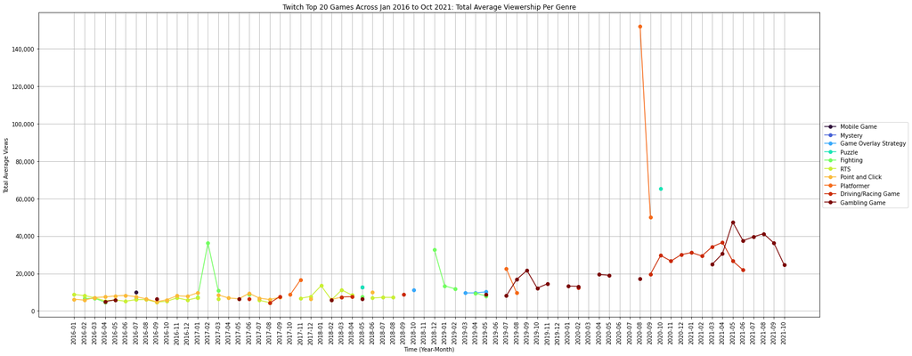

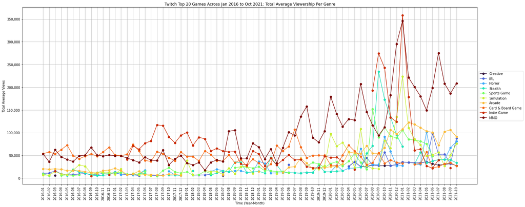

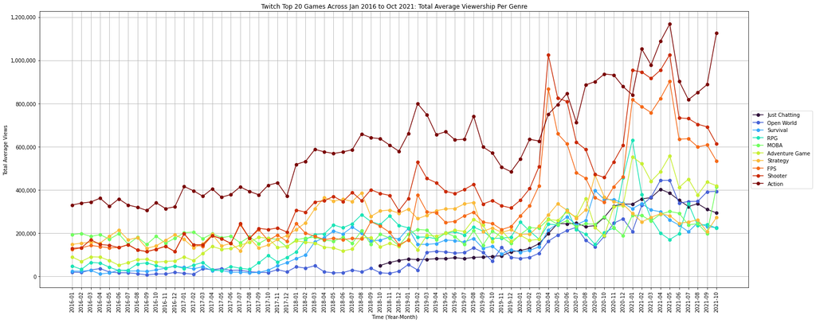

```python
genre_list = list(genre_counts.keys())

genres_total_viewers = []

# Sorting genres by total average viewers count
for genre in genre_list:
    data_by_genre = data.loc[data["Genre"].str.contains(genre)]
    genres_total_viewers.append((genre, data_by_genre['Avg_viewers'].sum()))

genres_total_viewers.sort(key=lambda x: x[1])

# Split into 3 lists
genre_chunks = list()
chunk_size = 10

for i in range(0, len(genres_total_viewers), chunk_size):
    genre_chunks.append(genres_total_viewers[i:i+chunk_size])

# Add nice colors
colors = cm.turbo(np.linspace(0, 1, 10))

# Plotting the groups of genres
for genres in genre_chunks:
    plt.figure(figsize=(25, 10))

    for (c, genre) in zip(colors,  [g[0] for g in genres]):
        data_by_genre = data.loc[data["Genre"].str.contains(genre)]
        grouped = data_by_genre.groupby(["Date"])["Avg_viewers"].sum().reset_index()
        view_data = dates_df.merge(grouped, how='left', on='Date')
        plt.plot_date(
            view_data['Date'],
            view_data['Avg_viewers'],
            fmt='-o',
            label=genre,
            color=c)

    plt.legend(loc='center left', bbox_to_anchor=(1, 0.5))
    plt.title('Twitch Top 20 Games Across Jan 2016 to Oct 2021: Total Average Viewership Per Genre')
    plt.ylabel('Total Average Views')
    plt.xlabel('Time (Year-Month)')
    plt.xticks(rotation=90)
    ax = plt.gca()
    ax.get_yaxis().set_major_formatter(
        tick.FuncFormatter(lambda x, p: format(int(x), ',')))

    plt.grid()
```

Another cool thing to note is that we now have our top 10 most popular genres based on the viewership of games belonging to the specific genres! Interestingly, the number one genre is Action, again! Since Action has the highest number of unique popular games, it may explain why it is also the number one genre based on viewership (more Action-type games = more people who know of Action-type games = more people encouraged to watch Action-type game streams).

### Twitch Top 10 Genres: Total Monthly Stream Time Per Genre

**Starting from this section, we will only use the top 10 most popular genres given from the previous section for better readability and analysis.**

In this section, we will create another line graph to demonstrate the total monthly stream time per genre for each month between January 2016 and October 2021. This graph will help us to visualize how many hours are invested by Twitch streamers in each genre; it gives us an idea on how popular a genre is from the perspective of a streamer. Additionally, it can help new streamers to figure out the competition for each genre, as more hours invested for a genre could also mean that more streamers would focus on that particular genre.

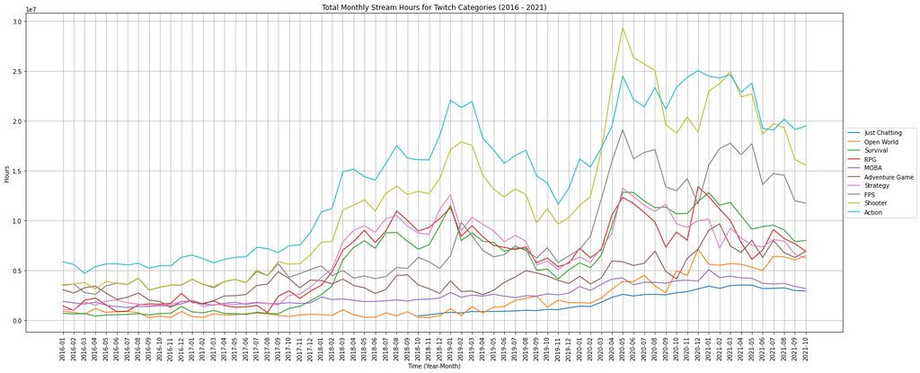

```python
# Grab the top 10 genres
top_10_genres = [g[0] for g in genre_chunks[2]]

# Plotting the line graph
plt.figure(figsize=(25,10))

for genre in top_10_genres:
    data_by_genre = data.loc[data["Genre"].str.contains(genre)]
    grouped = data_by_genre.groupby(["Date"])["Hours_Streamed"].sum().reset_index()

    stream_data = dates_df.merge(grouped, how='left', on='Date')

    plt.plot_date(
        stream_data['Date'],
        stream_data['Hours_Streamed'],
        fmt='-',
        label=genre)

plt.legend(loc='center left', bbox_to_anchor=(1, 0.5))
plt.xticks(rotation = 90)
plt.title("Total Monthly Stream Hours for Twitch Categories (2016 - 2021)")
plt.xlabel("Time (Year-Month)")
plt.ylabel("Hours")
plt.grid()
```

**Observations**: Once again, Action remains as the number one genre! Although, between March 2020 and August 2021, Action struggles to stay on top, while Shooter battles Action for the first place! Beginning of February 2020, we can see that Shooter rapidly gains stream time, and in the next month, it reaches where Action is. Afterwards, Shooter dominates Action in stream time and stays in first place before going back down to second place in September 2020. Essentially, we can presume that Action is a popular genre for both streamers and viewers! So, new streamers should be aware that Action-type gaming streams can attract both viewers *and* competition from other streamers…

### Twitch Top 10 Genres: Total Average Viewers Per Streamer By Genre

Let us analyze the average viewers per streamer by each genre. Here, we are using the average viewer ratio (Avg_viewer_ratio) column in data, which is the total average views column divided by the total streamers column for every game. We will sum up the average viewer ratios for all relating games in each genre for the respective dates (monthly) and then take the mean from the resulting sum, giving us the data for the average viewers per streamer by each genre. The resulting line graph gives us an estimate of how many viewers a streamer could possibly have while streaming a game in the specific genre.

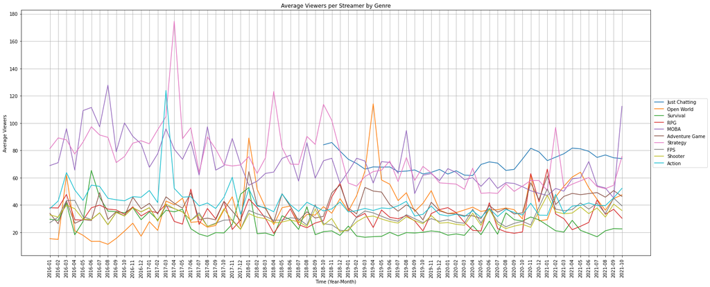

```python
# Plotting the line graph
plt.figure(figsize=(25, 10))
for genre in top_10_genres:
    # Process on the specific genre
    data_by_genre = data.loc[data["Genre"].str.contains(genre)]
    grouped = data_by_genre.groupby(["Date"])["Avg_viewer_ratio"].mean().reset_index()

    view_data = dates_df.merge(grouped, how='left', on='Date')

    plt.plot_date(
        view_data['Date'],
        view_data['Avg_viewer_ratio'],
        fmt='-',
        label=genre)

plt.legend(loc='center left', bbox_to_anchor=(1, 0.5))
plt.xticks(rotation=90)
plt.title("Average Viewers per Streamer by Genre")
plt.ylabel("Average Viewers")
plt.xlabel("Time (Year-Month)")
plt.grid()
```

**Observations**: Surprisingly, Action was not consistently number one in this graph. We can see that Strategy peaks a few times, most notably, in April 2017, April 2018, October 2018, and February 2021. We can also find that MOBA peaks a few times, especially in October 2021, where it dominates the other genres in the total average viewers per streamer. However, if we take a closer look at the graph, Just Chatting did amazingly well seeing how it suddenly appears on the graph starting in October 2018. Afterwards, Just Chatting remains above 60 viewers on average, and sometimes, it places number one compared to the other genres. Ultimately, if we only base off this graph, then streaming about a game in either MOBA, Strategy, or Just Chatting could attract a good number of viewers; they would be able to reach one of the requirements for joining the Affiliate program (i.e. reaching an average of 3 or more concurrent viewers for a stream).

### Twitch Top 10 Genres: Total Average Genre Rank Over Time

Now, we will find the average genre rank across each month between January 2016 and October 2021. To find the average genre rank, we will sum up the ranks for all the games belonging to the specific genre and then take the mean from the resulting sum for each month. This line graph shows us which genres tend to be more popular compared to other genres; it demonstrates the consistency of ranking for each genre.

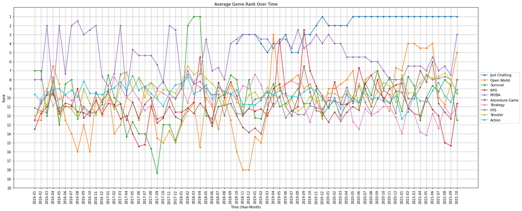

```python
# Plotting the line graph
plt.figure(figsize=(25, 10))
for genre in top_10_genres:
    # Process on the specific genre
    data_by_genre = data.loc[data["Genre"].str.contains(genre)]
    grouped = data_by_genre.groupby(["Date"])["Rank"].mean().reset_index()

    rank_data = dates_df.merge(grouped, how='left', on='Date')

    plt.plot_date(
        rank_data['Date'],
        rank_data['Rank'],
        fmt='-o',
        markersize=4,
        label=genre)

plt.legend(loc='center left', bbox_to_anchor=(1, 0.5))
plt.xticks(rotation=90)
plt.yticks(np.arange(1, 21, 1.0))
plt.title("Average Genre Rank Over Time")
plt.ylabel("Rank")
plt.ylim([0, 20])
plt.xlabel("Time (Year-Month)")
plt.gca().invert_yaxis()
plt.grid()
```

**Observations:** The most striking feature of this graph is the ranking for Just Chatting. Although this genre did not appear on the chart until October 2018, it continues to remain in the top 5 rankings. Further, Just Chatting stays at the number one rank for over a year (05/2020 to 10/2021), dominating the other genres in ranking. Nonetheless, MOBA also generally performed very well in the rankings. Although its ranking fluctuates a lot, it is usually within the top 10 and above the majority. Additionally, we can see that the genres center around rank 10, with the exception of Just Chatting and MOBA, which implies that the genres we are looking at are equally popular.

### Twitch Top 10 Genres: Total Occurrences of a Genre in Top 20 Game Rankings

For our last graph in the Exploratory Data Analysis section, we will observe the total number of occurrences of a genre appearing in the top 20 game rankings for each month between January 2016 and October 2021. We calculate the occurrences by counting the number of games that belong to a specific genre in the top 20 game rankings for each month. The resulting graph will measure the variety of content that streamers can stream that is popular for each genre. Although similar to the first graph we created, this graph narrows down to the top 10 most popular genres, and it helps us to visualize the trends over each month instead.

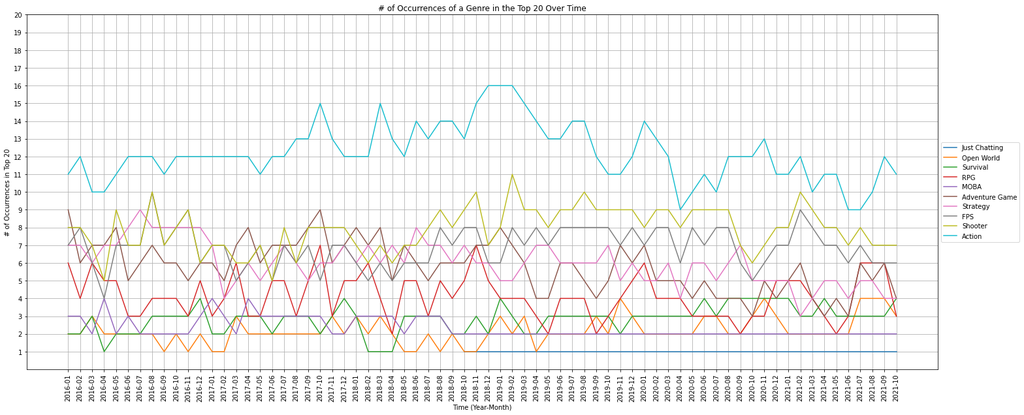

```python
# Plotting the line graph
plt.figure(figsize=(25, 10))
for genre in top_10_genres:
    # Process on the specific genre
    data_by_genre = data.loc[data["Genre"].str.contains(genre)]
    grouped = data_by_genre.groupby(["Date"])["Rank"].count().reset_index()

    occurrence_data = dates_df.merge(grouped, how='left', on='Date')

    plt.plot_date(
        occurrence_data['Date'],
        occurrence_data['Rank'],
        fmt='-',
        label=genre)

plt.legend(loc='center left', bbox_to_anchor=(1, 0.5))
plt.xticks(rotation=90)
plt.yticks(np.arange(1, 21, 1.0))
plt.title("# of Occurrences of a Genre in the Top 20 Over Time")
plt.ylabel("# of Occurrences in Top 20")
plt.ylim([0, 20])
plt.xlabel("Time (Year-Month)")
plt.grid()
```

**Observations:** Looking at the above graph, we can spot a high number of occurrences for Action, signifying that most games in the top 20 rankings are Action. Interestingly, MOBA’s counts vary between two and four games, while Just Chatting only has one “game” in the top 20 rankings. We do want to note that for Just Chatting, there is only one occurrence of it because Twitch counts any streams which mainly focuses on streamer-to-viewer interaction in this genre. Hence, events like streamers doing giveaways or challenges would count towards under Just Chatting.

### Hypothesis Testing & Machine Learning

#### Background Information

At this stage in the data science pipeline, you have statistically and graphically summarized some features of the data and perhaps have identified some correlations and relationships. The purpose of hypothesis testing is to statistically test your proposed relationships (your hypothesis). Hypothesis testing will involve two hypotheses, the null and alternative hypotheses. The null hypothesis states that there is *no* relationship while your alternative says there is. The goal of your tests is to reject your null hypothesis and we can do so through machine learning.

Machine learning allows us to build a model that describes the hypothesis we want to test. It also allows us to make predictions on the relationship beyond our current data. We will be using a linear regression which assumes the model you're building scales linearly. Once we have built our model, we can determine if our model shows a statistically relationship by the p-value of our parameters. Ideally, if they are < 0.05, we can say that a model parameter has some effect on the result.

#### Twitch Top 10 Genres: Average Viewers vs Hours Streamed

Now let’s try it!

As a novice streamer, you would want to know how successful you would be playing any of these top categories. Therefore, let's hypothesize that there is a relationship between how many viewers you gain and the amount of hours you stream for a category. Our null hypothesis will then be that there is no relationship between these two variables. For the top 10 genres, we plot the games under that genre as a scatter plot and fit a linear regression to it. For each genre, we print the model parameters and their p-values. The linear regression represents the number of average viewers a streamer would expect given the amount of hours they streamed in that genre per month.

```
################# Just Chatting #################
Parameter Model Values:
Intercept                      0.020589
Hours_Streamed_Per_Streamer    0.095153
dtype: float64

Parameter P-Values:
Intercept                      8.546564e-01
Hours_Streamed_Per_Streamer    6.283267e-07
dtype: float64
```

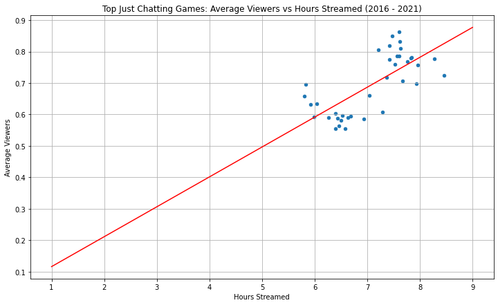

```
################# Open World #################
Parameter Model Values:
Intercept                     -0.194894
Hours_Streamed_Per_Streamer    0.081564
dtype: float64

Parameter P-Values:
Intercept                      8.358391e-03
Hours_Streamed_Per_Streamer    7.414598e-19
dtype: float64
```

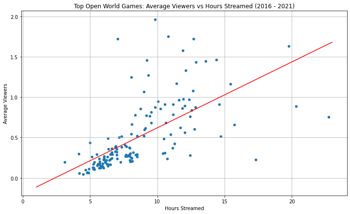

```
################# Survival #################
Parameter Model Values:
Intercept                     -0.085545
Hours_Streamed_Per_Streamer    0.045144
dtype: float64

Parameter P-Values:
Intercept                      2.222330e-02
Hours_Streamed_Per_Streamer    1.293725e-25
dtype: float64
```

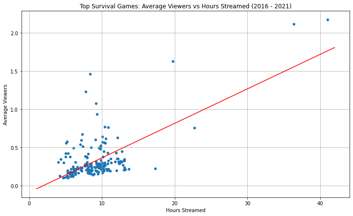

```
################# RPG #################
Parameter Model Values:
Intercept                     -0.034792
Hours_Streamed_Per_Streamer    0.050959
dtype: float64

Parameter P-Values:
Intercept                      5.820509e-01
Hours_Streamed_Per_Streamer    1.267775e-24
dtype: float64
```

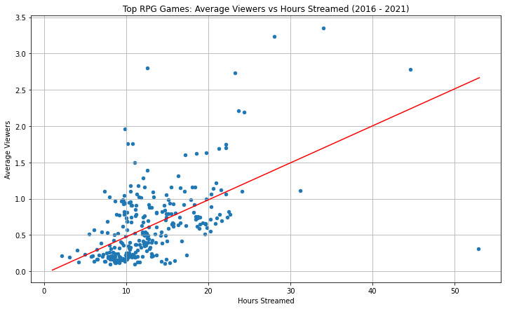

```
################# MOBA #################
Parameter Model Values:
Intercept                     -0.175672
Hours_Streamed_Per_Streamer    0.111772
dtype: float64

Parameter P-Values:
Intercept                      2.195834e-01
Hours_Streamed_Per_Streamer    2.823855e-20
dtype: float64
```

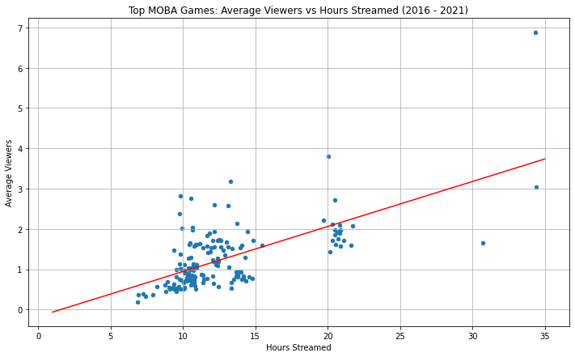

```
################# Adventure Game #################
Parameter Model Values:
Intercept                     -0.066606
Hours_Streamed_Per_Streamer    0.061234
dtype: float64

Parameter P-Values:
Intercept                      1.038991e-01
Hours_Streamed_Per_Streamer    6.302072e-51
dtype: float64
```

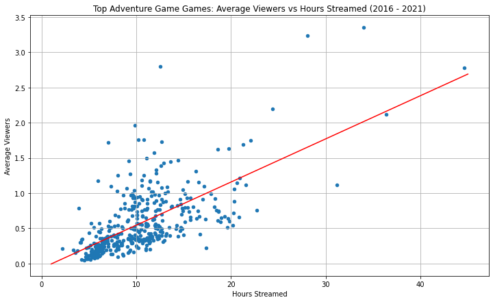

```
################# Strategy #################
Parameter Model Values:
Intercept                     -0.512598
Hours_Streamed_Per_Streamer    0.154966
dtype: float64

Parameter P-Values:
Intercept                      3.167497e-04
Hours_Streamed_Per_Streamer    7.836574e-33
dtype: float64
```

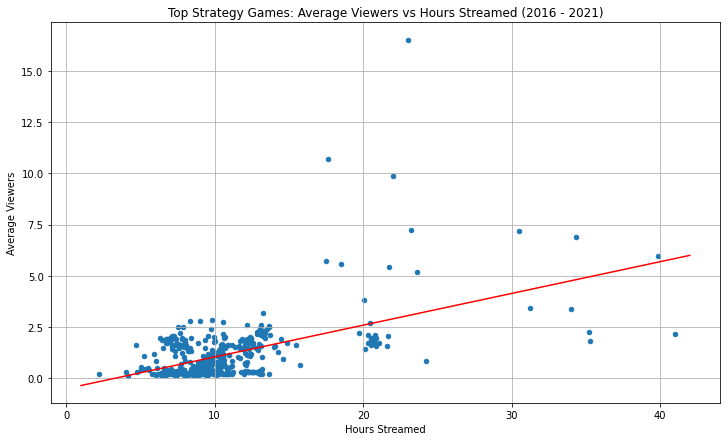

```
################# FPS #################
Parameter Model Values:
Intercept                      0.017566
Hours_Streamed_Per_Streamer    0.042472
dtype: float64

Parameter P-Values:
Intercept                      5.979783e-01
Hours_Streamed_Per_Streamer    1.187939e-36
dtype: float64
```

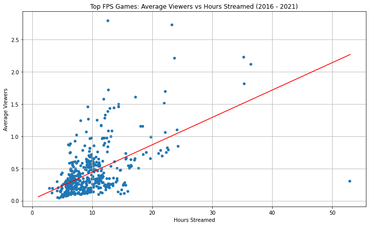

```
################# Shooter #################
Parameter Model Values:
Intercept                      0.003818
Hours_Streamed_Per_Streamer    0.042073
dtype: float64

Parameter P-Values:
Intercept                      9.021119e-01
Hours_Streamed_Per_Streamer    6.364632e-40
dtype: float64
```

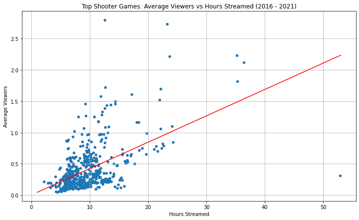

```
################# Action #################
Parameter Model Values:
Intercept                     -0.092525
Hours_Streamed_Per_Streamer    0.068121
dtype: float64

Parameter P-Values:
Intercept                      5.226156e-02
Hours_Streamed_Per_Streamer    4.391555e-52
dtype: float64
```

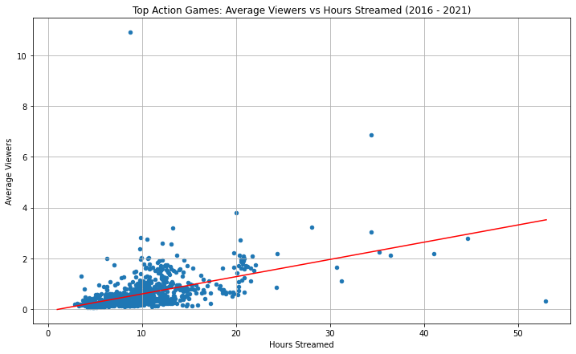

```python
# list to save linear regression coefficients
coeffs = []

# Plotting the scatter + linear regressions of each genre
for genre in top_10_genres:
    plt.figure()

    # Process on each genre
    print("################# {} #################".format(genre))
    data_by_genre = pd.DataFrame(data.loc[data["Genre"].str.contains(genre)])
    data_by_genre["Hours_Streamed_Per_Streamer"] = data_by_genre["Hours_Streamed"]/data_by_genre["Streamers"]
    data_by_genre["Avg_viewers_Per_Streamer"] = data_by_genre["Avg_viewers"]/data_by_genre["Streamers"]

    # Generating linear regression
    res = smf.ols(formula='Avg_viewers_Per_Streamer~Hours_Streamed_Per_Streamer', data=data_by_genre).fit()
    p = res.params
    coeffs.append((genre, p))

    print('Parameter Model Values:\n{}\n'.format(res.params))
    print('Parameter P-Values:\n{}'.format(res.pvalues))

    plot = data_by_genre.plot.scatter(
            x='Hours_Streamed_Per_Streamer',
            y='Avg_viewers_Per_Streamer',
            figsize=(12,7),
            grid=True,
            title='Top {} Games: Average Viewers vs Hours Streamed (2016 - 2021)'.format(genre),
            xlabel="Hours Streamed",
            ylabel="Average Viewers"
        )

    # Generate x-values for your regression line (two is sufficient)
    x = np.arange(1, data_by_genre["Hours_Streamed_Per_Streamer"].max()+1, step=1)

    # Plot regression line on the same axes, set x-axis limits
    plot.plot(x, p.Intercept + p.Hours_Streamed_Per_Streamer * x, color="red")

    plt.show()
    print("\n")
```

```python
# Sorting linear regression coefficients by slope (descending)
coeffs.sort(key=lambda x: x[1].Hours_Streamed_Per_Streamer, reverse=True)

for (genre, coeff) in coeffs:
    print('{}: {:.4f}'.format(genre, coeff.Hours_Streamed_Per_Streamer))
```

```
Strategy: 0.1550
MOBA: 0.1118
Just Chatting: 0.0952
Open World: 0.0816
Action: 0.0681
Adventure Game: 0.0612
RPG: 0.0510
Survival: 0.0451
FPS: 0.0425
Shooter: 0.0421
```

We interpret the rates in the following way: for each hour a streamer streams a game of a specific genre (G), the streamer should expect to gain the rate (R) more viewers in the stream. So if we use Strategy as the genre G, we say that every hour of Strategy content a streamer streams, that streamer can expect a gain in around 0.15 viewers. We can see that the genres with the highest Averages Viewers per Hours Streamed rate are Strategy, MOBA, and Just Chatting. On the other hand, Survival, FPS, and Shooter streams produce the lowest rates. This indicates that the model suggests that streaming content in Strategy, MOBA, or Just Chatting will increase a streamer's viewer count. Despite genres such as Survival, FPS, and Shooter being some of the top-streamed genres on Twitch, the number of streamers is much larger in comparison to the size of these genres' viewer bases. Therefore, a streamer would be competing against other streamers where the "return" of viewers is much smaller.

We can also observe that each genre's rate is well below 1. The model suggests that it will take a streamer around 10 to 20 hours to gain a single viewer on average. The small values for the rates tells us that it takes many of hours of dedication and streaming to build a channel and viewer base. Who would've thought that being a Twitch streamer would be so difficult?

Now that we have models that relate the average viewer count to the number of streaming hours of a particular category, we can calculate the amount of streaming hours it would take to have 3 concurrent viewers, one of the eligibility requirements for Twitch's Affiliate program. We essentially invert the model function to find the input that will output 3 for each model.

```python
# Calculating input for expected output for each genre
for (genre, coeff) in coeffs:
    print('{}: {:.2f} hours'.format(genre, (3.0 - coeff.Intercept) / coeff.Hours_Streamed_Per_Streamer))
```

```
Strategy: 22.67 hours
MOBA: 28.41 hours
Just Chatting: 31.31 hours
Open World: 39.17 hours
Action: 45.40 hours
Adventure Game: 50.08 hours
RPG: 59.55 hours
Survival: 68.35 hours
FPS: 70.22 hours
Shooter: 71.21 hours
```

Now we can see that if you want to get 3 concurrent viewers on average as fast as possible, you should stream Strategy content and expect to satisfy the concurrent viewer requirement after 22.67 hours.

### Conclusion

Twitch and the live streaming scene is very dynamic, being driven by the videogame market, and social and cultural trends. So starting out as a streamer, it may be difficult to know how to build your channel and online presence. To help new streamers, we tried to use data science to find a quantitative measure for building success, starting with getting into the Affiliate program. We used data on the top 200 games streamed every month from January 2016 to October 2021, narrowed down to the top 20 games each month, and the genres of those games in our analysis.

After reviewing the results and observations of our data analysis, we suggest the following for streamers eager to join the Twitch Affiliate program:

- The 10 most popular genres to stream are:
  - Action
  - Shooter
  - FPS
  - Strategy
  - Adventure Game
  - MOBA
  - RPG
  - Survival
  - Open World
  - Just Chatting
- Just Chatting has been the highest-ranked game/genre each month since May 2020.
- Action provides a streamer with the most variety of games to stream that are in the top 20 games each month, which would allow them to stream less hours on a single game.
- MOBA has ranked very highly throughout the past 6 years, but the selection of games is quite limited relative to other genres.
- Action, Shooter, and FPS games are the genres with the most hours streamed.
- MOBA, Strategy, and Just Chatting has the best average viewers per streamer. This was further supported by the linear regression models, where we found that streaming Strategy for 22.67 hours per month would be the fastest method to reaching an average 3 concurrent viewers.

#### Further Work

If we were to continue researching this topic, we would add data on the top streamers and their performance. In our current models and analysis, we assume every streamer has the same performance. In reality however, some streamers are more popular than others and skew the distribution of viewership and hours streamed. Game news, such as game release dates, could also be added to provide context on changes in trends.

Here are several sources for streamers and game data.

- https://twitchtracker.com/
- https://www.kaggle.com/aayushmishra1512/twitchdata
- https://www.kaggle.com/gregorut/videogamesales

#### Further Resources

- [Data Scraping](https://realpython.com/beautiful-soup-web-scraper-python/#what-is-web-scraping)
- [Exploratory Data Analysis](https://towardsdatascience.com/exploratory-data-analysis-8fc1cb20fd15)
- [Basic Overview of Machine Learning](https://www.sas.com/en_us/insights/analytics/machine-learning.html)
- [Hypothesis Testing](https://towardsdatascience.com/hypothesis-testing-for-data-scientists-everything-you-need-to-know-8c36ddde4cd2)
- [Linear Regression](https://machinelearningmastery.com/linear-regression-for-machine-learning/)